# Final Project

Eaton Shao

July 6, 2021

# Blogpost

## Background:

“Sport has the power to change the World” - This is a quote from first President of South Africa Nelson Mandela and is elective of what the Olympics means to many people. To put it in perspective, the Olympics is suppose to be the ultimate test in determining one’s aptitude in sport. Many people dedicate their whole lives for once chance to compete at the world stage and represent their country. In this way one might think that a great Olympian can come from any background from any place if they have the determination to be number one.

## Process:

But is there somehow a way to look at any existing trends to see what goes behind every great Olympian? Is it a matter of gifted genetics? Upbringing? It might even be things that no one would even consider such as what the weather is like in your country.

To answer these questions I’ve looked primarily at the “120 years of Olympic history: athletes and results” data set on Kaggle along with other data sets that record the GDP and Population of Countries to see if there’s any coloration between external factors and success.

## Summer or Winter?:

The data set includes data both from the Summer and Winter Olympics. We can look at the behavior of each Olympic game by season to see if trends in the Summer Olympics versus the Winter Olympics behave differently.

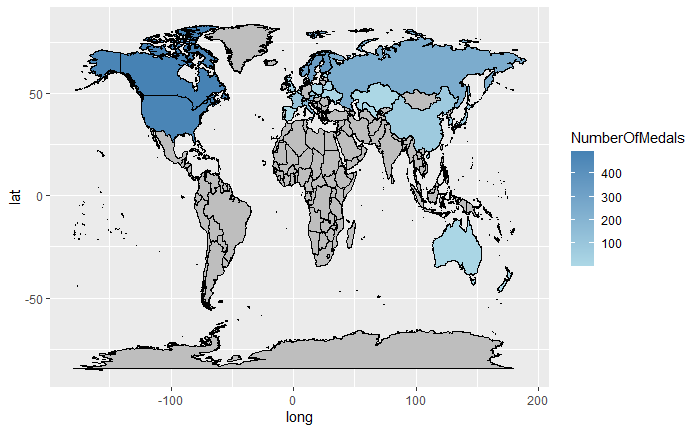

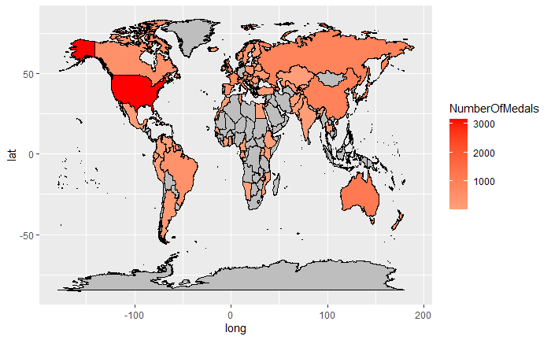

Here we can clearly see the differences in which countries compete in the Winter Olympics versus the Summer Olympics. At first glance it may seem obvious, countries in colder climates earn more medals than those located in warmer climates but if that were the case then why wouldn’t the inverse be true? Obviously geographical location isn’t the sole factor in these countries winning medals. The more reasonable answer is that these countries are better off economically and can invest in institutions where Olympic athletes can train for winter sports and summer sports while the countries towards the equator cannot and can only focus on events in the Summer Olympics.

## A Home Field Advantage:

Next we will look the home field advantage successes and see if it plays a role in Olympic success. A home field advantage is where a team does better when the Olympics are being held its own country. There are many hypotheses about why this may occur: Countries that hold Olympic games in their own countries have most likely held the games in the past (meaning they already have invested in the infrastructure for the games/sports to begin with), More support from home crowds, Referees leaning toward in favor for their own national athletes, etc. However the most accepted answer is that athletes have an easier time qualifying in their home country which means more participation and therefor more chances to win medals.

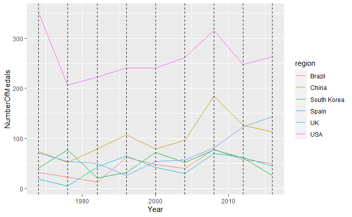

## The real defining factors?:

Finally the last factors to look were not included in the data set but would make sense to affect how successful countries would be in. If size and wealth of a country were the defining characteristics of a successful country then the implications could mean that citizens of a country would no longer want to compete under the same flag if it means not having the best chances of winning the Olympics. This would go against everything I had said previously about the Olympics being the ultimate test of one’s abilities regardless of background. Maybe it does matter where you’re born if you want to have the best shot of having earned one of the most highly held titles one can receive.

The data from the other data sets only goes back from 1960 so all our assumptions will be made from that point on, the data sets also have a lot of missing data so it’s fair to assume that poor countries with who had no systems at the time to conduct a census of the population/record GDP for the country will be left out of this evaluation.

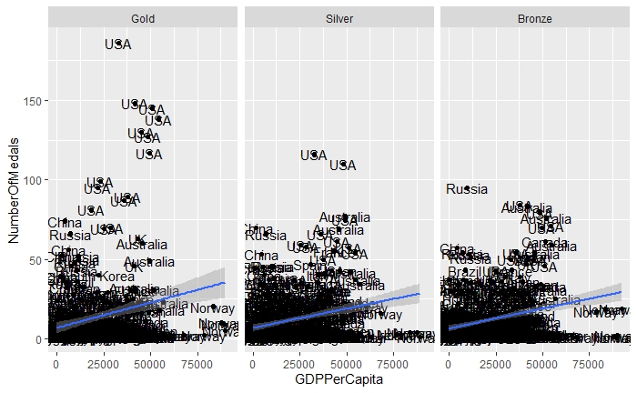

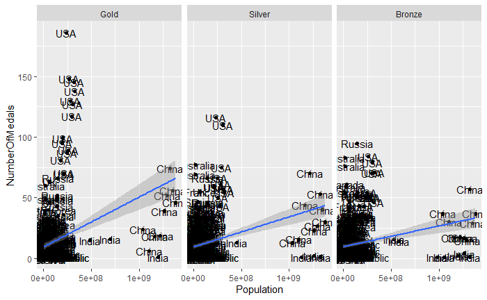

## Conclusion:

# Technical Analysis

## Abstract:

The Olympic Games has an ancient history but only recently has become what it is known as today within the past 200 years. In the beginning of the modern Olympics, competition was only limited to European nations but around the 1900s it became truly a world phenomenon. Often times a country’s performance in the Olympics is a measure of their capability and aptitude of a nation, but how true is this?

## Overview and Motivation:

As I was brainstorming research topics I was trying to find different data sets that had an interest in but none that really stood out to me. Many of which were very untidy/incomplete or had limited information with very few variables for each observation. When I stumbled upon the 120 years of Olympic history: athletes and results" data set on Kaggle I thought it was fitting due to the approching Olympic games in Tokyo this year and was reminded of this YouTube video: “https://youtu.be/J5i8gm7h8fE” I had seen a while back and wondered what other trends could be explored by analyzing this data.

## Initial Questions:

I felt like this was a good data set to utilize in my project due to the size and many variables such as ID, Names, Sex, Age, Weight, Height, Teams, spanning 120 years. There are 271116 observations with 15 columns. That alone I thought would be enough to use for the entirety of this data analysis. However it became clear that there are other factors that are outside of this data set such as the economy and size of each country with affect their performance in each Olympic game.

Initially I was more focused on the aspect of each Country’s performance and maybe looking at that of the individual athlete.

The questions I had hoped to answer were:

1. “Do countries with warmer/colder climates fare better in the games Summer/Winter Olympics?”
2. “Does the size of the athlete matter in different events? Which sports have the biggest/smallest athletes and which have the most variability of athlete size when it comes to success? Is there any trend over time that reflects this?”
3. “Which Olympic sports have the most longevity of an athlete? What are the sports where athletes have the longest careers?”
4. “Do countries that compete in their home city end up performing better?”

Lastly, I wanted to build a predictive model that would’ve been able to make a prediction about the Tokyo 2020 Olympics to see who would come out on top but I wasn’t really sure how to approach that. I managed to build a train a linear regression model to predicted the number of Gold Medals earned based on other existing factors.

## Data:

I used the following packages to wrangle/visualize the data

```r
library(dplyr)
library(tidyverse)
```

```r
library(ggplot2)
library(tidymodels)
library(patchwork)
```

The data sets I used for this analysis were all from Kaggle. The first being the main focus of my analysis and the others I used to look for other factors involving the success of each country.

```r
athlete <- read_csv("athlete_events.csv")
str(athlete)
```

```
## spec_tbl_df [271,116 x 15] (S3: spec_tbl_df/tbl_df/tbl/data.frame)
##  $ ID    : num [1:271116] 1 2 3 4 5 5 5 5 5 5 ...
##  $ Name  : chr [1:271116] "A Dijiang" "A Lamusi" "Gunnar Nielsen Aaby" "Edgar Lindenau Aabye" ...
##  $ Sex   : chr [1:271116] "M" "M" "M" "M" ...
##  $ Age   : num [1:271116] 24 23 24 34 21 21 25 25 27 27 ...
##  $ Height: num [1:271116] 180 170 NA NA 185 185 185 185 185 185 ...
##  $ Weight: num [1:271116] 80 60 NA NA 82 82 82 82 82 82 ...
##  $ Team  : chr [1:271116] "China" "China" "Denmark" "Denmark/Sweden" ...
##  $ NOC   : chr [1:271116] "CHN" "CHN" "DEN" "DEN" ...
##  $ Games : chr [1:271116] "1992 Summer" "2012 Summer" "1920 Summer" "1900 Summer" ...
##  $ Year  : num [1:271116] 1992 2012 1920 1900 1988 ...
##  $ Season: chr [1:271116] "Summer" "Summer" "Summer" "Summer" ...
##  $ City  : chr [1:271116] "Barcelona" "London" "Antwerpen" "Paris" ...
##  $ Sport : chr [1:271116] "Basketball" "Judo" "Football" "Tug-Of-War" ...
##  $ Event : chr [1:271116] "Basketball Men's Basketball" "Judo Men's Extra-Lightweight" "Football Men's Football" "Tug-Of-War Men's Tug-Of-War" ...
##  $ Medal : chr [1:271116] NA NA NA "Gold" ...
##  - attr(*, "spec")=
##   .. cols(
##   ..   ID = col_double(),
##   ..   Name = col_character(),
##   ..   Sex = col_character(),
##   ..   Age = col_double(),
##   ..   Height = col_double(),
##   ..   Weight = col_double(),
##   ..   Team = col_character(),
##   ..   NOC = col_character(),
##   ..   Games = col_character(),
##   ..   Year = col_double(),
##   ..   Season = col_character(),
##   ..   City = col_character(),
##   ..   Sport = col_character(),
##   ..   Event = col_character(),
##   ..   Medal = col_character()
##   .. )
```

```r
regions <- read_csv("noc_regions.csv")
str(regions)
```

```
## spec_tbl_df [230 x 3] (S3: spec_tbl_df/tbl_df/tbl/data.frame)
##  $ NOC   : chr [1:230] "AFG" "AHO" "ALB" "ALG" ...
##  $ region: chr [1:230] "Afghanistan" "Curacao" "Albania" "Algeria" ...
##  $ notes : chr [1:230] NA "Netherlands Antilles" NA NA ...
##  - attr(*, "spec")=
##   .. cols(
##   ..   NOC = col_character(),
##   ..   region = col_character(),
##   ..   notes = col_character()
##   .. )
```

Going into this I was unaware of how much cleaning up I had to do to the data set. At the beginning I had not made sure that all of the missing values were taken care of and didn’t make sure that each variable was the right of the right type. This made my exploritory analysis very difficult in the begining and gave me results that did not look right. I then went back and made sure to fix all my data before approaching again.

```r
athlete <- athlete %>% select(-Games)
regions <- regions %>% select(-notes)
```

I found that each csv file also contained columns that were of duplicate information or just useless so I decided to just remove them using the select function and subtracting the columns that we didn’t need like we learned in class.

```r
athlete <- athlete %>% left_join(regions, by = "NOC")
head(athlete)
```

```
## # A tibble: 6 x 15
##      ID Name    Sex     Age Height Weight Team   NOC    Year Season City   Sport
##   <dbl> <chr>   <chr> <dbl>  <dbl>  <dbl> <chr>  <chr> <dbl> <chr>  <chr>  <chr>
## 1     1 A Diji~ M        24    180     80 China  CHN    1992 Summer Barce~ Bask~
## 2     2 A Lamu~ M        23    170     60 China  CHN    2012 Summer London Judo
## 3     3 Gunnar~ M        24     NA     NA Denma~ DEN    1920 Summer Antwe~ Foot~
## 4     4 Edgar ~ M        34     NA     NA Denma~ DEN    1900 Summer Paris  Tug-~
## 5     5 Christ~ F        21    185     82 Nethe~ NED    1988 Winter Calga~ Spee~
## 6     5 Christ~ F        21    185     82 Nethe~ NED    1988 Winter Calga~ Spee~
## # ... with 3 more variables: Event <chr>, Medal <chr>, region <chr>
```

```r
colSums(is.na(athlete))
```

```
##     ID   Name    Sex    Age Height Weight   Team    NOC   Year Season   City
##      0      0      0   9474  60171  62875      0      0      0      0      0
##  Sport  Event  Medal region
##      0      0 231333    370
```

The next step was to left_join the region table with the athlete table because each “Team” name didn’t necessarily correspond to a country name. By using the NOC code as a key I was able to make sure that each athlete would have a home country attributed to them.

The data is still very untidy as seen especially with the Medal variable, athletes who had not won any kind of medal were given a missing value instead.

```r
gdp <- read_csv("gdp_data.csv")
gdp <- gdp %>% select(NOC = "Code", Year, GDP, GDPPerCapita = "GDP-Per-Capita")

population <- read_csv("WorldPopulation.csv")
population <- population %>%
  pivot_longer(cols = 5:62, names_to = "Year", values_to = "Population") %>%
  mutate(Year = as.integer(Year)) %>%
  select(-c('Country','Indicator Name', 'Indicator Code')) %>% rename(NOC = "Country Code")
gdp <- na.omit(gdp)
population <- na.omit(population)
head(gdp)
```

```
## # A tibble: 6 x 4
##   NOC    Year           GDP GDPPerCapita
##   <chr> <dbl>         <dbl>        <dbl>
## 1 ARG    1960 120808873524.        5711.
## 2 AUS    1960 206734197138.       19245.
## 3 AUT    1960  99489765787.       13954.
## 4 BDI    1960    561670812.         193.
## 5 BEL    1960 133384673233.       14466.
## 6 BEN    1960   1260456133.         504.
```

```r
head(population)
```

```
## # A tibble: 6 x 3
##   NOC    Year Population
##   <chr> <int>      <dbl>
## 1 ABW    1960      54211
## 2 ABW    1961      55438
## 3 ABW    1962      56225
## 4 ABW    1963      56695
## 5 ABW    1964      57032
## 6 ABW    1965      57360
```

```r
colSums(is.na(gdp))
```

```
##          NOC         Year          GDP GDPPerCapita
##            0            0            0            0
```

```r
colSums(is.na(population))
```

```
##        NOC       Year Population
##          0          0          0
```

I loaded the next two data sets, although they had more variables assigned to each row I thought that it was only necessary to keep the ones pertaining to GDP and Population as those were the only variables I would be looking at. Both tables were wide so I needed to perse the values from every year into their own column so I could join each table back to the original data set.

```r
athlete <- athlete %>% left_join(population, by = c("NOC", "Year")) %>%
  left_join(gdp, by = c("NOC", "Year"))
head(athlete)
```

```
## # A tibble: 6 x 18
##      ID Name    Sex     Age Height Weight Team   NOC    Year Season City   Sport
##   <dbl> <chr>   <chr> <dbl>  <dbl>  <dbl> <chr>  <chr> <dbl> <chr>  <chr>  <chr>
## 1     1 A Diji~ M        24    180     80 China  CHN    1992 Summer Barce~ Bask~
## 2     2 A Lamu~ M        23    170     60 China  CHN    2012 Summer London Judo
## 3     3 Gunnar~ M        24     NA     NA Denma~ DEN    1920 Summer Antwe~ Foot~
## 4     4 Edgar ~ M        34     NA     NA Denma~ DEN    1900 Summer Paris  Tug-~
## 5     5 Christ~ F        21    185     82 Nethe~ NED    1988 Winter Calga~ Spee~
## 6     5 Christ~ F        21    185     82 Nethe~ NED    1988 Winter Calga~ Spee~
## # ... with 6 more variables: Event <chr>, Medal <chr>, region <chr>,
## #   Population <dbl>, GDP <dbl>, GDPPerCapita <dbl>
```

By joining each table by the NOC code and by the Year I was able to make sure there weren’t any repeat observations

```r
athlete$Sex <- as.factor(athlete$Sex)
athlete$Season <- as.factor(athlete$Season)
athlete$Medal[is.na(athlete$Medal)] <- "No Medal"
athlete$Medal <- as.factor(athlete$Medal) %>%
  factor(levels = c("Gold", "Silver", "Bronze", "No Medal"),
          ordered=TRUE)

athlete <- na.omit(athlete)
colSums(is.na(athlete))
```

```
##           ID         Name          Sex          Age       Height       Weight
##            0            0            0            0            0            0
##         Team          NOC         Year       Season         City        Sport
##            0            0            0            0            0            0
##        Event        Medal       region   Population          GDP GDPPerCapita
##            0            0            0            0            0            0
```

The next step was making sure that each variable got assigned the right type. The Medal variable was something I had a hard time with when using this data set. I was reluctant to parse the data into different variables each with their own count to avoid making the table wide. However I ended up doing it anyway when it became necessary for model fitting. Although most of my analysis goes around this, it would definitely be something I would have changed sooner looking back.

After I had all the columns of the right type I omitted the rows with missing values in either that were originally part of the athlete table like Height, Weight, Age ; but also missing information in the GDP and population tables. This would definitely skew my data to focus solely on the more developed countries who had the resources to record all this different type of information. Maybe another approach would have been to directly assign the missing variables what would be the averages of each column for that country?

```r
medal_count <- athlete %>%
  filter(Medal != "No Medal") %>%
  group_by(Name, Year, Event) %>%
  count(Medal) %>%
  pivot_wider(names_from = Medal, values_from  = n,  values_fill = 0 )

athlete <- athlete %>%
  left_join(medal_count, by = c("Name", "Year", "Event")) %>%
  mutate_if(is.numeric,coalesce,0)
```

As stated above, the Medals variable was particularly hard to work with because each entry was qualitative rather than quantitative and contained a lot of empty data. Most observations didn’t have any medals so that was something I really had to make sure I filtered out when doing my analysis.

## Exploratory Data Analysis:

Question 1: “Do countries with warmer/colder climates fare better in the games Summer/Winter Olympics?”

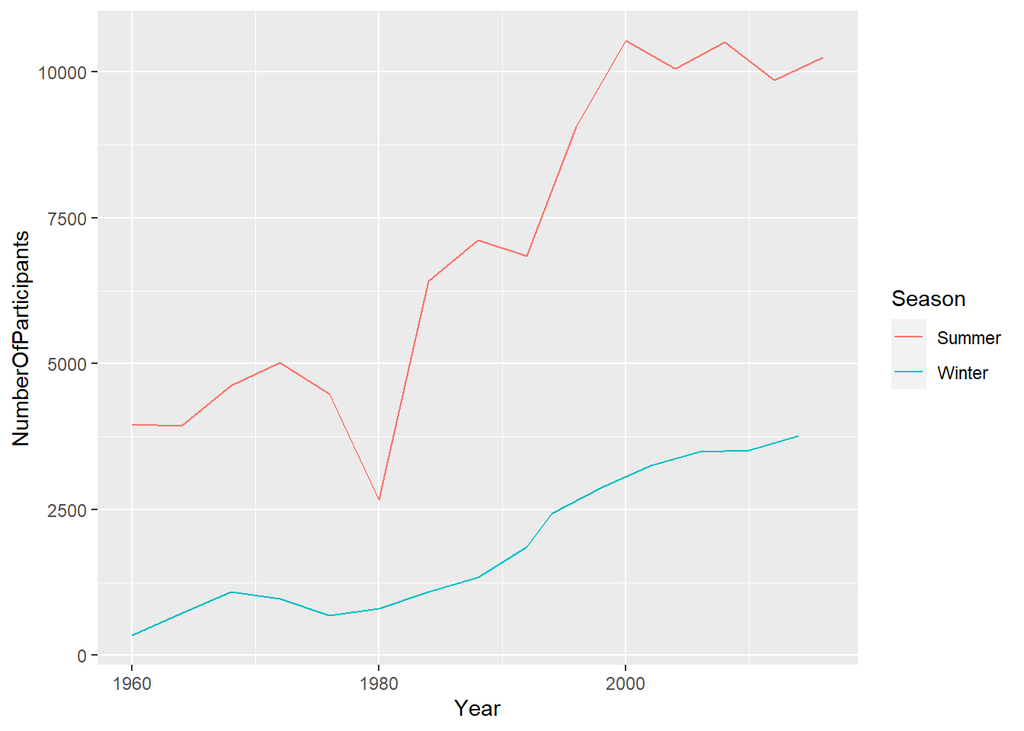

```r
athlete %>%
  group_by(Year, Season) %>%
  summarise(NumberOfParticipants = n()) %>%
  ggplot(aes(x = Year, y = NumberOfParticipants)) +
  geom_line(aes(color = Season))
```

First I decided to group each observation by Year and Season to count the number of participants in each Olympic game. There is definitely a big disparity between the number of participants in the Summer Olympics vs the Winter Olympics which raised my suspicion.

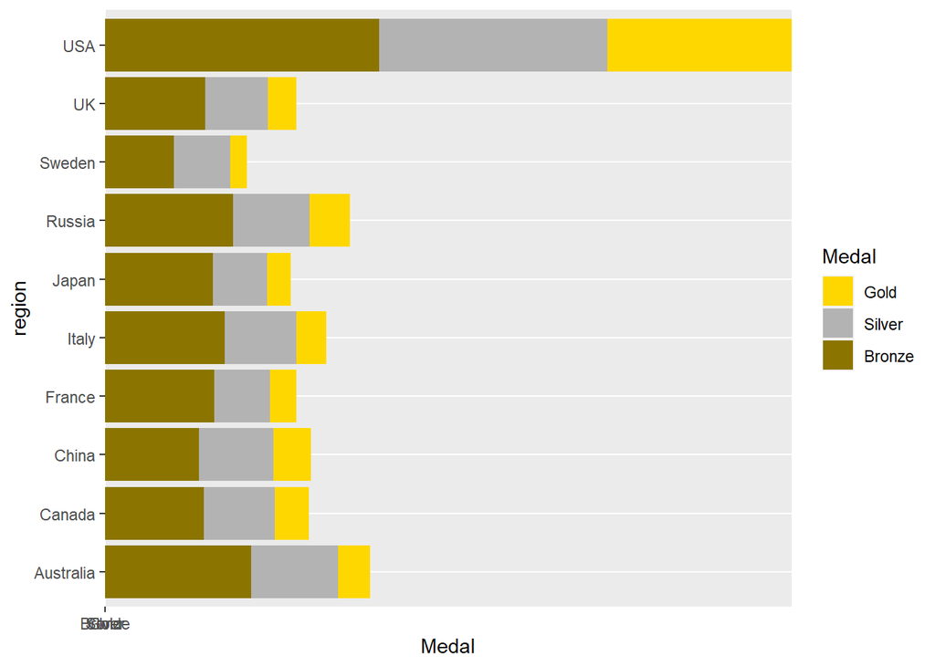

```r
top10 <- athlete %>%
  group_by(region) %>%
  filter(Medal != "No Medal") %>%
  summarize(NumberOfMedals = length(Medal)) %>%
  arrange(desc(NumberOfMedals)) %>%
  ungroup() %>%
  head(10)

athlete %>% filter(region %in% top10$region, Medal != 'No Medal') %>%
  ggplot(aes(x=region, y = Medal, fill = Medal)) +
  geom_bar(stat="identity") + coord_flip() +
  scale_fill_manual(values=c("gold1","gray70","gold4"))
```

Here I just decided to create a bar graph to help myself visualize the distribution of medals for the top performing countries. The United States is the clear powerhouse of the Olympics with more than half double the number of medals of any other country in the top 10.

All these countries are (arguably) rather well developed. With the exception maybe being China and Russia. This was confirming my idea that countries with the highest GDP-per-capita’s are the ones who end up winning the most medals. The other exceptions made up for the fact that their populations were much bigger. The United States clearly benefited from both these factors making it the most successful

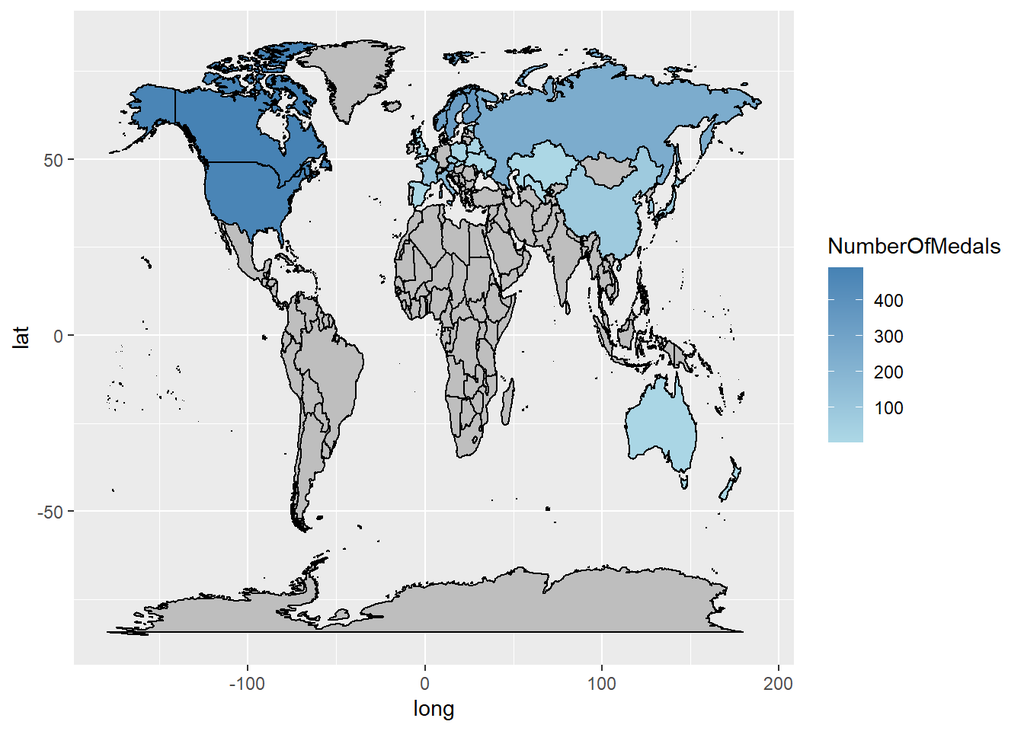

```r
winter_medals <- athlete %>%
  filter(Season == "Winter", Medal != "No Medal") %>%
  group_by(region) %>%
  summarise(NumberOfMedals = n()) %>%
  arrange(desc(NumberOfMedals))

map_winter <- map_data("world") %>%
  left_join(winter_medals, by = 'region')

map_winter %>% ggplot(aes(x = long, y = lat, group = group)) +
  geom_polygon(aes(fill = NumberOfMedals), color = 'black') +scale_fill_gradient(low = 'lightblue', high = 'steelblue', na.value = 'grey')
```

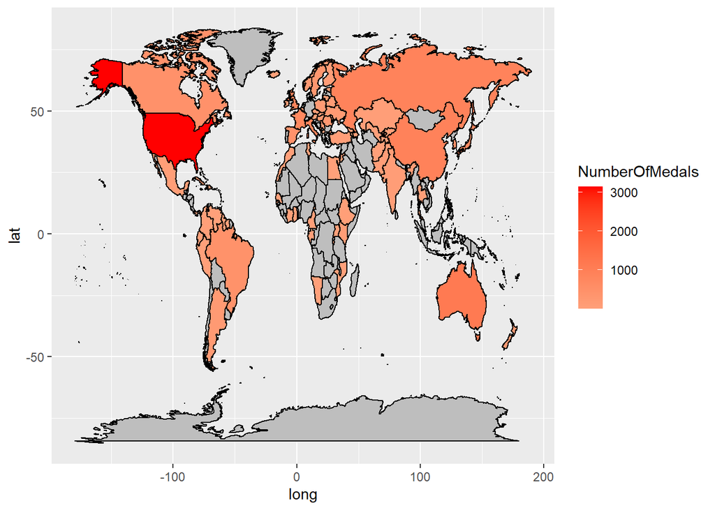

```r
summer_medals <- athlete %>%
  filter(Season == "Summer", Medal != "No Medal") %>%
  group_by(region) %>%
  summarise(NumberOfMedals = n()) %>%
  arrange(desc(NumberOfMedals))

map_summer <- map_data("world") %>%
  left_join(summer_medals, by = 'region')

map_summer %>% ggplot(aes(x = long, y = lat, group = group)) +
  geom_polygon(aes(fill = NumberOfMedals), color = 'black') + scale_fill_gradient(low = 'lightsalmon', high = 'red', na.value = 'grey')
```

I was able to filter the countries by Season and medals received. One mistake I made early on was not filtering the medals that had not been given and that gave me incorrect data because the summarise function would count them anyway. This gave me counts that were in the thousands and included a lot more countries that would not have been included. Having the first graph helped me realize that this should not be the case and I went back and saw my error.

One thing I think I could have improved was the gradient on the world map. I couldn’t find any colors that gave a clear in between shade given the low and high colors. I settled by picking 2 shades of the same color that weren’t too far off from each other. Maybe if I had sequenced the count it would give clear defined colors?

Question 2: “Does the size of the athlete matter in different events? Which sports have the biggest/smallest athletes and which have the most variability of athlete size when it comes to success? Is there any trend over time that reflects this?”

```r
mean_measurements <- athlete %>% group_by(Sport) %>%
  summarise(Avg_Height = mean(Height),
            Avg_Weight = mean(Weight),
            Avg_Age = mean(Age))


tallest <- mean_measurements %>% arrange(desc(Avg_Height)) %>% head(10) %>% .$Sport
shortest <- mean_measurements %>% arrange(desc(Avg_Height)) %>% tail(10) %>% .$Sport

heaviest <- mean_measurements %>% arrange(desc(Avg_Weight)) %>% head(10) %>% .$Sport
lightest <- mean_measurements %>% arrange(desc(Avg_Weight)) %>% tail(10) %>% .$Sport

oldest <-  mean_measurements %>% arrange(desc(Avg_Age)) %>% head(10) %>% .$Sport
youngest <- mean_measurements %>% arrange(desc(Avg_Age)) %>% tail(10) %>% .$Sport


tallest
```

```
##  [1] "Basketball"       "Volleyball"       "Beach Volleyball" "Rowing"
##  [5] "Water Polo"       "Handball"         "Baseball"         "Bobsleigh"
##  [9] "Ice Hockey"       "Tennis"
```

```r
shortest
```

```
##  [1] "Freestyle Skiing"          "Short Track Speed Skating"
##  [3] "Softball"                  "Synchronized Swimming"
##  [5] "Weightlifting"             "Figure Skating"
##  [7] "Rhythmic Gymnastics"       "Diving"
##  [9] "Trampolining"              "Gymnastics"
```

```r
heaviest
```

```
##  [1] "Bobsleigh"        "Baseball"         "Basketball"       "Water Polo"
##  [5] "Ice Hockey"       "Handball"         "Rowing"           "Weightlifting"
##  [9] "Beach Volleyball" "Judo"
```

```r
lightest
```

```
##  [1] "Table Tennis"              "Short Track Speed Skating"
##  [3] "Ski Jumping"               "Triathlon"
##  [5] "Diving"                    "Figure Skating"
##  [7] "Trampolining"              "Gymnastics"
##  [9] "Synchronized Swimming"     "Rhythmic Gymnastics"
```

```r
youngest
```

```
##  [1] "Football"                  "Boxing"
##  [3] "Ski Jumping"               "Short Track Speed Skating"
##  [5] "Synchronized Swimming"     "Figure Skating"
##  [7] "Diving"                    "Gymnastics"
##  [9] "Swimming"                  "Rhythmic Gymnastics"
```

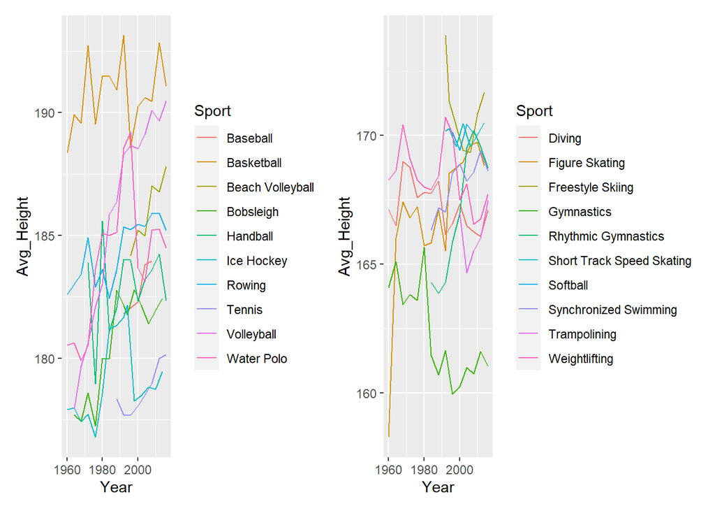

```r
tallplot <- athlete %>% filter(Sport %in% tallest) %>% group_by(Year, Sport) %>% summarize(Avg_Height = mean(Height)) %>% ggplot(aes(x = Year, y = Avg_Height)) + geom_line(aes(color = Sport))
heavyplot <- athlete %>% filter(Sport %in% heaviest) %>% group_by(Year, Sport) %>% summarize(Avg_Weight = mean(Weight)) %>% ggplot(aes(x = Year, y = Avg_Weight)) + geom_line(aes(color = Sport))
oldplot <- athlete %>% filter(Sport %in% oldest) %>% group_by(Year, Sport) %>% summarize(Avg_Age = mean(Age)) %>% ggplot(aes(x = Year, y = Avg_Age)) + geom_line(aes(color = Sport))
shortplot <- athlete %>% filter(Sport %in% shortest) %>% group_by(Year, Sport) %>% summarize(Avg_Height = mean(Height)) %>% ggplot(aes(x = Year, y = Avg_Height)) + geom_line(aes(color = Sport))
lightplot <- athlete %>% filter(Sport %in% lightest) %>% group_by(Year, Sport) %>% summarize(Avg_Weight = mean(Weight)) %>% ggplot(aes(x = Year, y = Avg_Weight)) + geom_line(aes(color = Sport))
youngplot <- athlete %>% filter(Sport %in% heaviest) %>% group_by(Year, Sport) %>% summarize(Avg_Age = mean(Age)) %>% ggplot(aes(x = Year, y = Avg_Age)) + geom_line(aes(color = Sport))
tallplot + shortplot
```

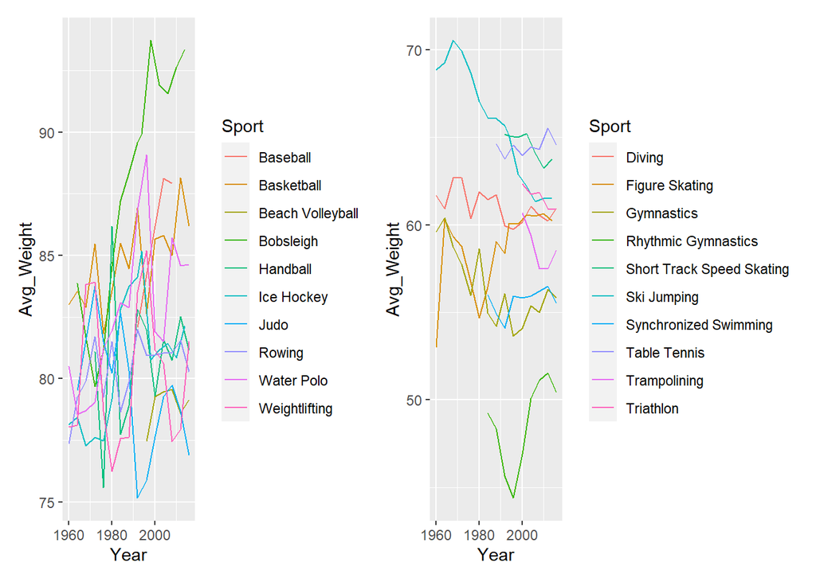

```r
heavyplot + lightplot
```

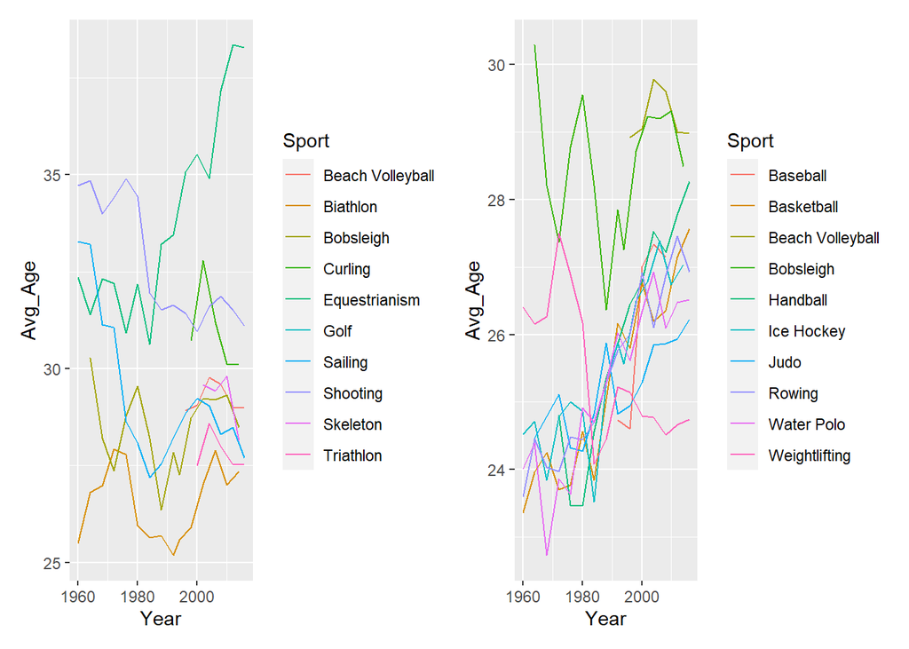

```r
oldplot + youngplot
```

I decided to only pair the graphs that were evaluated by the same attribute using the patchwork library, if I were to try to do any more it would’ve resulted in the graphs being unreadable due to the legend on the side taking up too much space. Some of the sports seen aren’t a good representation of the tallest/heaviest athletes due to the fact that there are only a few participants of that sport. Maybe a better way to have approached this would be to filter sports that have appeared at least 100 times to get a better idea of the trends involving changing demographics of athletes.

Question 3: “Which Olympic sports have the most longevity of an athlete? What are the sports where athletes have the longest careers?”

```r
athlete %>%
  group_by(Name,Sport) %>%
  summarise(Carreer = paste(min(Year), max(Year), sep = "-"),
             Span = n_distinct(Year)) %>%
  arrange(desc(Span)) %>%
  head(20)
```

```
## # A tibble: 20 x 4
## # Groups:   Name [20]
##    Name                                       Sport         Carreer    Span
##    <chr>                                      <chr>         <chr>     <int>
##  1 "Ian Millar"                               Equestrianism 1972-2012    10
##  2 "Hubert Raudaschl"                         Sailing       1964-1996     9
##  3 "Francisco Boza Dibos"                     Shooting      1980-2016     8
##  4 "Lesley Allison Thompson-Willie"           Rowing        1984-2016     8
##  5 "Andrew James Hoy"                         Equestrianism 1984-2012     7
##  6 "Giovanni Pellielo"                        Shooting      1992-2016     7
##  7 "Jean-Michel Jacques Georges Hubert Saive" Table Tennis  1988-2012     7
##  8 "Jeannie Longo-Ciprelli"                   Cycling       1984-2008     7
##  9 "Jess ngel Garca Bragado"                  Athletics     1992-2016     7
## 10 "John Michael Plumb"                       Equestrianism 1960-1992     7
## 11 "Karl Ragnar Skanker (Eriksson-)"          Shooting      1972-1996     7
## 12 "Kerstin Ullasdotter Palm"                 Fencing       1964-1988     7
## 13 "Lars-Erik Jrgen Persson"                  Table Tennis  1988-2012     7
## 14 "Leander Adrian Paes"                      Tennis        1992-2016     7
## 15 "Mark James Todd"                          Equestrianism 1984-2016     7
## 16 "Nicholas David \"Nick\" Skelton"          Equestrianism 1988-2016     7
## 17 "Noriaki Kasai"                            Ski Jumping   1992-2014     7
## 18 "Tinne Eva Caroline Wilhelmsson-Silfvn"    Equestrianism 1992-2016     7
## 19 "Aida Gabriella Mohamed"                   Fencing       1996-2016     6
## 20 "Albert Mikhaylovich Demchenko"            Luge          1994-2014     6
```

This turned out to be one of the easiest questions to answer in addition to the one which sparked my interest to use this data set in the first place. I used the same technique as the Batting data set we used in lab5 to create new columns for each athlete’s career and “lifespan”. The person with the longest history in the Olympics being Ian Millar competing in Equestrianism. Most of the Sports seen here are the same/similar to those seen in the oldest list for Question 2. This makes sense since the people with the most longevity are probably the ones who can still perform at an old age and don’t require much intensity.

Question 4: “Do countries that compete in their home city end up performing better?”

This was one of the questions I had in my project proposal that turned how to be a more defining factor that I had initially thought. This is a real phenomenon that is seen not only in the Olympics but with sports teams and other competitions. Although many argue about the real reason behind it, it doesn’t take away from the fact that it still exists.

```r
athlete %>% filter(Season == "Summer", Year %in% 1984:2016) %>% .$City %>% unique()
```

```
## [1] "Barcelona"      "London"         "Sydney"         "Atlanta"
## [5] "Rio de Janeiro" "Athina"         "Beijing"        "Los Angeles"
## [9] "Seoul"
```

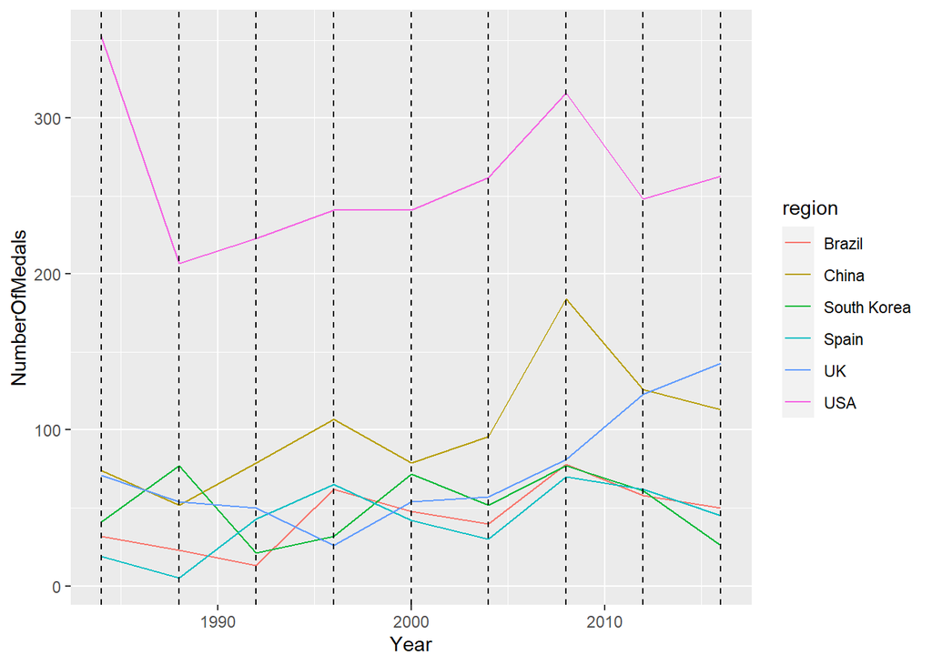

```r
athlete %>%
  filter(Season == "Summer", Year %in% 1984:2016, region %in% c('Spain', 'UK', 'Austrailia', 'USA', 'China', 'Brazil', 'South Korea'), Medal != "No Medal") %>%
  group_by(region, Year) %>% summarise(NumberOfMedals = length(Medal)) %>%
  ggplot(aes(x = Year, y = NumberOfMedals)) + geom_line(aes(color = region)) +
  geom_vline(xintercept = seq(1984, 2016, 4), linetype="dashed")
```

Even so we can see that for the most part, for the years on which countries competed within their own city, they won more medals than the previous year.

Question 5: “How big of a role does population and GDP play when predicting the success of a country in the Olympics?”

Although this was hinted at with the first question. It’s time to see how much of a role each one of these factors has when it comes to the number of medals won.

First I filtered by country, year, and population size/GDP-per-capita but only used the data from the Summer Olympics. I plotted a scatter plot and fit a regression line to see that there definitely was a positive correlation between those two factors.

```r
poplm <- athlete %>%
  group_by(region, Year, Population) %>%
  filter(Season == "Summer", Medal != "No Medal", ) %>%
  count(Medal) %>%
  rename(NumberOfMedals = n) %>%
  ggplot(aes(x = Population, y = NumberOfMedals)) +
  geom_text(aes(label= region)) + geom_point() + geom_jitter() +
  geom_smooth(method = lm) + facet_wrap(~Medal)
```

```r
athlete %>%
  group_by(region ,NOC, Year, GDPPerCapita) %>%
  filter(Season == "Summer" , Medal != "No Medal") %>%
  count(Medal) %>%
  rename(NumberOfMedals = n) %>%
  ggplot(aes(x = GDPPerCapita, y = NumberOfMedals)) +
  geom_text(aes(label= region)) + geom_point() + geom_jitter() +
  geom_smooth(method = lm) + facet_wrap(~Medal)
```

Obviously the United States is the standout winner when it comes to Olympic success but this also showed some interesting aspects. The fact that China and India are outliers when it comes to number of medals plotted against population yet there aren’t many outliers in the GDP plot might suggest that population is a bigger factor than GDP when it comes to success.

```r
  athlete <- athlete %>% group_by(region,Year) %>%
             mutate(GoldCount = sum(Gold),
                    SilverCount = sum(Silver),
                    BronzeCount = sum(Bronze),
                    TotalCount =sum(Gold+Silver+Bronze))
```

Here is when I decided to use the wide table I implemented at the beginning to use for regression.

```r
mod <- lm(TotalCount ~ Population, data = athlete)
summary(mod)$coefficients
```

```
##                 Estimate   Std. Error  t value Pr(>|t|)
## (Intercept) 4.543396e+01 1.920172e-01 236.6140        0
## Population  8.541204e-08 7.068197e-10 120.8399        0
```

```r
mod <- lm(TotalCount ~ GDPPerCapita , data = athlete)
summary(mod)$coefficients
```

```
##                  Estimate   Std. Error   t value Pr(>|t|)
## (Intercept)  27.298861954 3.004596e-01  90.85702        0
## GDPPerCapita  0.001131222 9.911767e-06 114.12915        0
```

Question 6: “Can we build a model that can predict the number of gold medals won based on other factors?”

```r
athlete_splits <- initial_split(athlete, prop = 0.8)

train <- training(athlete_splits)
test <- testing(athlete_splits)

mod_lm <- linear_reg(mode = "regression") %>%
  set_engine("lm") %>%
  fit(GoldCount ~ Population + GDPPerCapita + SilverCount + BronzeCount, data = train)

mod_lm %>% predict(new_data = train) %>%
  mutate(GoldCount = train$GoldCount) %>%
  rmse(truth = GoldCount, estimate = .pred)
```

```
## # A tibble: 1 x 3
##   .metric .estimator .estimate
##   <chr>   <chr>          <dbl>
## 1 rmse    standard        18.9
```

```r
mod_lm %>% predict(new_data = test) %>%
  mutate(GoldCount = test$GoldCount) %>%
  rmse(truth = GoldCount, estimate = .pred)
```

```
## # A tibble: 1 x 3
##   .metric .estimator .estimate
##   <chr>   <chr>          <dbl>
## 1 rmse    standard        19.1
```

My original goal was to make a model which would be able to predict the number of gold medals a country would earn based on it’s GDP-per-capita, opulation, number of silver medals and number of bronze medals.

This could potentially be a good estimator, the model is not overfit and the testing data is very close to the training data.

## Final Analysis:

It is clear that there exist external factors that lead to a Countries success with GPD and population being the biggest factor of all of them. Most of my exploratory analysis was focused on going through the data set itself and trying to find trends within the athletes and countries without realizing that it’s more relevant to find out what factors are causing this success in the first place rather than just the things that show success, still it was an important part of understanding the data set. Most of my data analysis was spent looking at graphs but a more compelling exercise might be to write more prediction models to find out the likelihood of lets say, the probability that an athlete competing in their host country wins a medal. I choose to leave only the most relevant parts of my exploratory analysis within my blog post which I felt had the most correlation to the success of a country.

## Related Work:

https://www.bloomberg.com/graphics/2016-olympics-usoc-return-on-investment/ https://www.rd.com/list/13-olympic-moments-that-changed-history/ https://fivethirtyeight.com/features/is-there-home-field-advantage-at-the-olympics/

## Links to Datasets:

https://www.kaggle.com/heesoo37/120-years-of-olympic-history-athletes-and-results https://www.kaggle.com/jonscheaffer/worldwide-gdp-history-19602016 https://www.kaggle.com/centurion1986/countries-population